# Data 606 Final Project

12/3/2020

## Overview

As someone about to enter the world of parenthood I thought it would be interesting to look at the potential relationship between having children and one’s level of happiness. The specific research question I had *planned on* asking is:

*Is there a difference in levels of happiness between non-parents and parents?*

However, mid-way through my original analysis I realized that there were issues with the data which rendered it less useful so I re-framed the question as:

*Is there a difference in levels of life satisfaction between non-parents and parents?*

**Null hypothesis:** There is no difference in average levels of life satisfaction between non-parents and parents

**Alternative hypothesis:** There is some difference in average levels of life satisfaction between non-parents and parents

## Data / Data Collection

The data is “Wave 7” from the World Values Survey (WSV), and the details - including a link to where the full data set can be downloaded, is below. However, please note that the date used in this file is an extract I made from that original data set that only includes data for the variables relevant for this project. The original file includes 536 separate variables.

**Citation:**

WVS wave 7 (2017-2020): Haerpfer, C., Inglehart, R., Moreno, A., Welzel, C., Kizilova, K., Diez-Medrano J., M. Lagos, P. Norris, E. Ponarin & B. Puranen et al. (eds.). 2020. World Values Survey: Round Seven (2017 to 2020) Country-Pooled Datafile. Madrid, Spain & Vienna, Austria: JD Systems Institute & WVSA Secretariat [Version: http://www.worldvaluessurvey.org/WVSDocumentationWV7.jsp].

## Key Variables

- The dependent (response) variable is level of life satisfaction, which is technical a categorical (ordinal) variable with values ranging from 1 to 10 but per discussion with the professor will be treated as a quantitative variable for this project.
- The main independent (explanatory) variable will be whether the respondent is a parent, which is a binary variable (is parent, or is not parent).
- The secondary independent variable will be the country they live in, which is categorical (nominal).

```
## Rows: 69,806
## Columns: 4
## $ country_code      <chr> "AND", "AND", "AND", "AND", "AND", "AND", "AND", ...
## $ num_children      <int> 2, 0, 0, 1, 0, 3, 1, 2, 0, 1, 1, 2, 1, 2, 3, 0, 0...
## $ life_satisfaction <int> 10, 9, 9, 8, 7, 10, 5, 8, 8, 10, 8, 8, 10, 7, 10,...
## $ region            <chr> "Europe & Central Asia", "Europe & Central Asia",...
```

## Exploring the Data

| life_satisfaction | num_rows |
| --- | --- |
| 1 | 2026 |
| 2 | 1013 |
| 3 | 2289 |
| 4 | 3296 |
| 5 | 8566 |
| 6 | 7807 |
| 7 | 11369 |
| 8 | 13688 |
| 9 | 7118 |
| 10 | 12634 |

## Exploring the Data

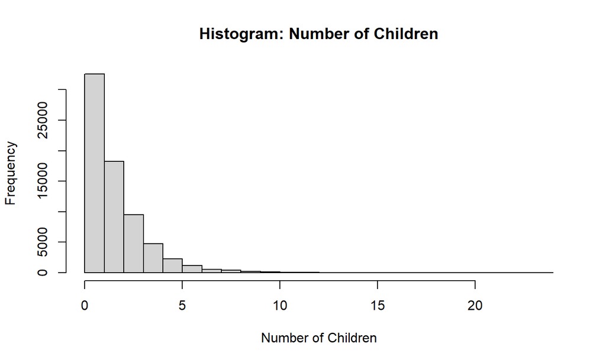

## Exploring the Data

Summary by avg life satisfaction, descending

```r
top_n(arrange(df_summarized, desc(avg_life_satisfaction)), 10)
```

```
## # A tibble: 10 x 3
##    country_code avg_life_satisfaction avg_num_children
##    <chr>                        <dbl>            <dbl>
##  1 KGZ                           8.37             2.49
##  2 MEX                           8.15             2.47
##  3 TJK                           7.95             2.79
##  4 PAK                           7.67             2.65
##  5 BOL                           7.47             2.26
##  6 PHL                           7.37             2.64
##  7 JOR                           6.87             3.13
##  8 NGA                           5.61             2.30
##  9 ZWE                           4.95             2.61
## 10 IRQ                           4.46             2.44
```

## Exploring the Data

Summary by avg num of children, descending

```r
top_n(arrange(df_summarized, desc(avg_num_children)), 10)
```

```
## # A tibble: 10 x 3
##    country_code avg_life_satisfaction avg_num_children
##    <chr>                        <dbl>            <dbl>
##  1 JOR                           6.87             3.13
##  2 TJK                           7.95             2.79
##  3 PAK                           7.67             2.65
##  4 PHL                           7.37             2.64
##  5 ZWE                           4.95             2.61
##  6 KGZ                           8.37             2.49
##  7 MEX                           8.15             2.47
##  8 IRQ                           4.46             2.44
##  9 NGA                           5.61             2.30
## 10 BOL                           7.47             2.26
```

## Exploring the Data

Box Plots of little use based on ordinal variable, though differing IQRs are interesting

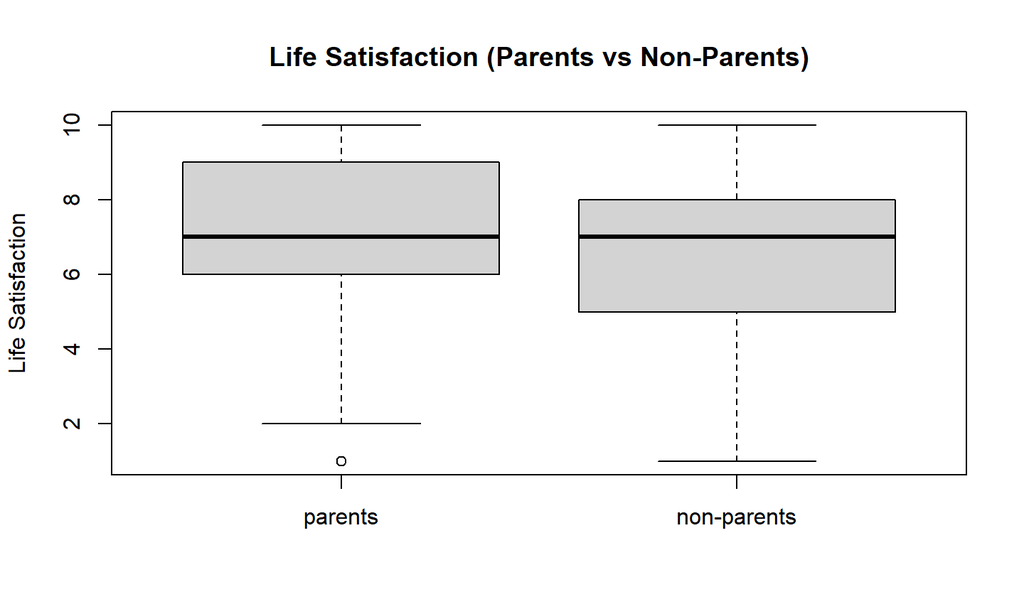

```r
# Boxplots of life satisfaction levels - parents vs non-parents
boxplot(parents_df$life_satisfaction, nonparents_df$life_satisfaction, names = c("parents", "non-parents"), ylab = "Life Satisfaction", main = "Life Satisfaction (Parents vs Non-Parents)")
```

## Summary Statistics and Inference

To determine whether there is a significant difference between the two population means (parents and non-parents), a T-test was used.

As a first step, we need to evaluate the two Central Limit Conditions:

- **Independence, extended:** The WVS website says ‘All countries employed random probability representative samples of the adult population’, so this condition is satisfied.
- **Normality:** The sample size is significantly larger than 30 for each group, as detailed below, so assuming there are no clear outliers this condition is satisfied.

## Summary Statistics and Inference

To further check normality histograms and QQ plots were created for each group:

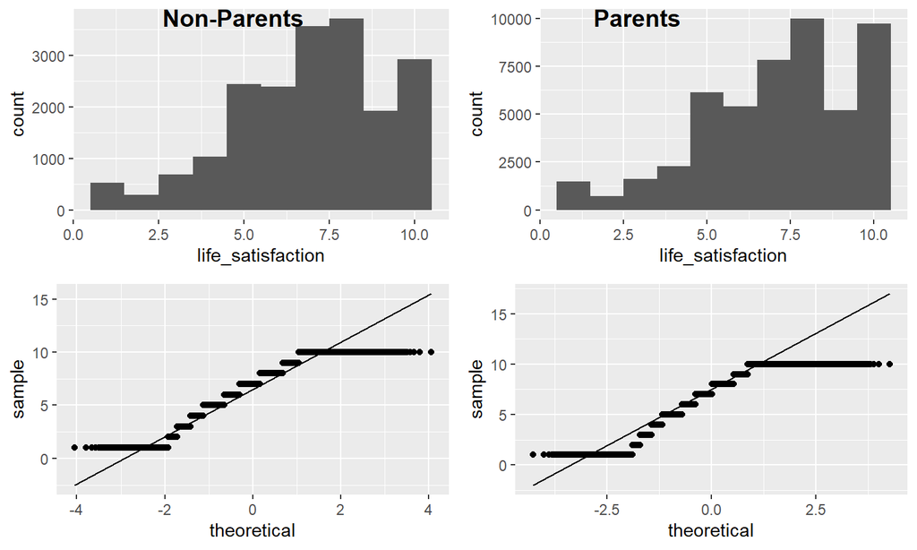

## Summary Statistics and Inference

After confirming the conditions for inference have been met, summary statistics and a t-test can be performed. The t-test was first done manually and then done again via an r function to compare / confirm results.

```
## Nonparents:
##  Mean: 6.93
##  Number of Observations (N): 19481
##  Standard Deviation: 2.296118
```

```
## Parents:
##  Mean: 7.12
##  Number of Observations (N): 50325
##  Standard Deviation: 2.22387
```

```
## Standard Error: 0.01920687
## Degrees of Freedom: 19480
```

Results of manually performed t-test

[output not shown]

## Summary Statistics and Inference

Same t-test but using built-in t.test function, which confirms the same result

```r
autotest <- t.test(parents_df$life_satisfaction, nonparents_df$life_satisfaction)
autotest
```

```
##
##  Welch Two Sample t-test
##
## data:  parents_df$life_satisfaction and nonparents_df$life_satisfaction
## t = 10.196, df = 36471, p-value < 2.2e-16
## alternative hypothesis: true difference in means is not equal to 0
## 95 percent confidence interval:
##  0.1559755 0.2302117
## sample estimates:
## mean of x mean of y
##  7.120099  6.927006
```

## Taking Another Look

I performed some more analysis to see if perhaps there was a difference in regions, which there seems to be.

The data seems to indicate that satisfaction is quite a bit better after 13 children, and Latin America seems to be the highest scoring region.

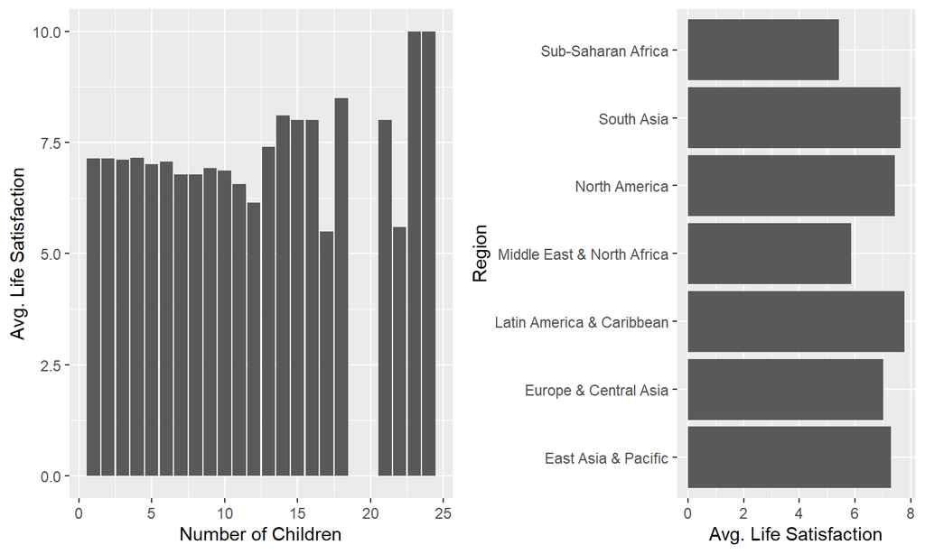

## Another T-Test: Is This Normal?

Another normality check, this time for parents w/ 14+ children

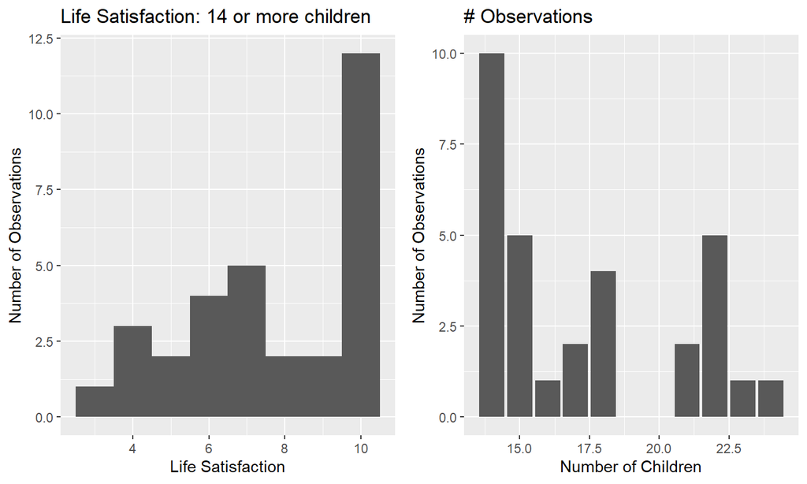

## Another T-Test

```r
# Run another t-test, this time focused using data for parents with 14 or more children
t.test(parents_happy$life_satisfaction, nonparents_df$life_satisfaction)
```

```
##
##  Welch Two Sample t-test
##
## data:  parents_happy$life_satisfaction and nonparents_df$life_satisfaction
## t = 1.8148, df = 30.089, p-value = 0.07954
## alternative hypothesis: true difference in means is not equal to 0
## 95 percent confidence interval:
##  -0.09395254  1.59477964
## sample estimates:
## mean of x mean of y
##  7.677419  6.927006
```

## One Last Try

What if we changed the approach a bit and use a one tailed t-test?

Surprise! Based on this test, with a p value of under .05 we can reject the null hypothesis and say that parents with 14 or more children are on average more satisfied with their lives than non-parents.

```
##
##  Welch Two Sample t-test
##
## data:  parents_happy$life_satisfaction and nonparents_df$life_satisfaction
## t = 1.8148, df = 30.089, p-value = 0.03977
## alternative hypothesis: true difference in means is greater than 0
## 95 percent confidence interval:
##  0.04866957        Inf
## sample estimates:
## mean of x mean of y
##  7.677419  6.927006
```

## Conclusion

- There is a statistically significant difference in levels of life satisfaction between parents and non-parents
- The difference appears to be positive
- Ordinal variables are not ideal for quantitative analysis
- One-tailed tests can be deceiving
- ANOVA would perhaps have been a better test